# Ensemble_Techniques_Project

```python
# Importing the reqired basic modules
import numpy as np
import pandas as pd
import os
import matplotlib.pyplot as plt
%matplotlib inline
import seaborn as sns
sns.set_style()
```

```python
#importing modules required for preprocessing data
from sklearn.model_selection import train_test_split
from sklearn import preprocessing as prep

# importing models
from sklearn.linear_model import LinearRegression,LogisticRegression
from sklearn.naive_bayes import GaussianNB as nb
from sklearn.neighbors import KNeighborsClassifier as knn
from sklearn import svm
from sklearn.tree import DecisionTreeClassifier as dt
from sklearn.ensemble import BaggingClassifier,AdaBoostClassifier,GradientBoostingClassifier,RandomForestClassifier,StackingClassifier

# importing modules required for evaluation
from sklearn import metrics
import time
```

### Loading the new dataset

```python
# importing the file into a dataframe and displaying top 5 rows
pk=pd.read_csv('Parkinsons')
pk.head()
```

|  | name | MDVP:Fo(Hz) | MDVP:Fhi(Hz) | MDVP:Flo(Hz) | MDVP:Jitter(%) | MDVP:Jitter(Abs) | MDVP:RAP | MDVP:PPQ | Jitter:DDP | MDVP:Shimmer | ... | Shimmer:DDA | NHR | HNR | status | RPDE | DFA | spread1 | spread2 | D2 | PPE |
| --- | --- | --- | --- | --- | --- | --- | --- | --- | --- | --- | --- | --- | --- | --- | --- | --- | --- | --- | --- | --- | --- |
| 0 | phon_R01_S01_1 | 119.992 | 157.302 | 74.997 | 0.00784 | 0.00007 | 0.00370 | 0.00554 | 0.01109 | 0.04374 | ... | 0.06545 | 0.02211 | 21.033 | 1 | 0.414783 | 0.815285 | -4.813031 | 0.266482 | 2.301442 | 0.284654 |
| 1 | phon_R01_S01_2 | 122.400 | 148.650 | 113.819 | 0.00968 | 0.00008 | 0.00465 | 0.00696 | 0.01394 | 0.06134 | ... | 0.09403 | 0.01929 | 19.085 | 1 | 0.458359 | 0.819521 | -4.075192 | 0.335590 | 2.486855 | 0.368674 |
| 2 | phon_R01_S01_3 | 116.682 | 131.111 | 111.555 | 0.01050 | 0.00009 | 0.00544 | 0.00781 | 0.01633 | 0.05233 | ... | 0.08270 | 0.01309 | 20.651 | 1 | 0.429895 | 0.825288 | -4.443179 | 0.311173 | 2.342259 | 0.332634 |
| 3 | phon_R01_S01_4 | 116.676 | 137.871 | 111.366 | 0.00997 | 0.00009 | 0.00502 | 0.00698 | 0.01505 | 0.05492 | ... | 0.08771 | 0.01353 | 20.644 | 1 | 0.434969 | 0.819235 | -4.117501 | 0.334147 | 2.405554 | 0.368975 |
| 4 | phon_R01_S01_5 | 116.014 | 141.781 | 110.655 | 0.01284 | 0.00011 | 0.00655 | 0.00908 | 0.01966 | 0.06425 | ... | 0.10470 | 0.01767 | 19.649 | 1 | 0.417356 | 0.823484 | -3.747787 | 0.234513 | 2.332180 | 0.410335 |

5 rows × 24 columns

```python
#checking the data info for datatypes, shape and column details
pk.info()
```

```
<class 'pandas.core.frame.DataFrame'>
RangeIndex: 195 entries, 0 to 194
Data columns (total 24 columns):
 #   Column            Non-Null Count  Dtype
---  ------            --------------  -----
 0   name              195 non-null    object
 1   MDVP:Fo(Hz)       195 non-null    float64
 2   MDVP:Fhi(Hz)      195 non-null    float64
 3   MDVP:Flo(Hz)      195 non-null    float64
 4   MDVP:Jitter(%)    195 non-null    float64
 5   MDVP:Jitter(Abs)  195 non-null    float64
 6   MDVP:RAP          195 non-null    float64
 7   MDVP:PPQ          195 non-null    float64
 8   Jitter:DDP        195 non-null    float64
 9   MDVP:Shimmer      195 non-null    float64
```

[output cut: 16 more lines]

```python
#checking for null/NA values
pk.isna().sum().sum()
```

```
0
```

```python
# Checking the number of unique values for each attribute
for cols in pk.columns:
    print(cols,"-",pk[cols].nunique())
```

```
name - 195
MDVP:Fo(Hz) - 195
MDVP:Fhi(Hz) - 195
MDVP:Flo(Hz) - 195
MDVP:Jitter(%) - 173
MDVP:Jitter(Abs) - 19
MDVP:RAP - 155
MDVP:PPQ - 165
Jitter:DDP - 180
MDVP:Shimmer - 188
MDVP:Shimmer(dB) - 149
Shimmer:APQ3 - 184
Shimmer:APQ5 - 189
MDVP:APQ - 189
Shimmer:DDA - 189
NHR - 185
HNR - 195
status - 2
RPDE - 195
DFA - 195
spread1 - 195
spread2 - 194
D2 - 195
PPE - 195
```

```python
## Dropping the unique identifier "name" from the dataframe
pk.drop(columns='name', inplace=True)

## Updating the datatype of output attribute "status" to categorical
pk['status']= pd.Categorical(pk['status'])
```

#### Initial impression of the dataset:

Based on the initial impression of the dataset, following observations can be made:

1. The dataset has only 195 records which might pose a problem considering how we usually require large number of observations when training a model. Higher record count would help in better model training.
2. The number of unique values for many attributes is almost equal to the number of records. This could lead to multiple completely unique records helping in data training.
3. There are no missing values but the records have difference in scale in attributes. The input values shall need be scaled in preprocessing for distance based model training.

### Attribute analysis for relationships

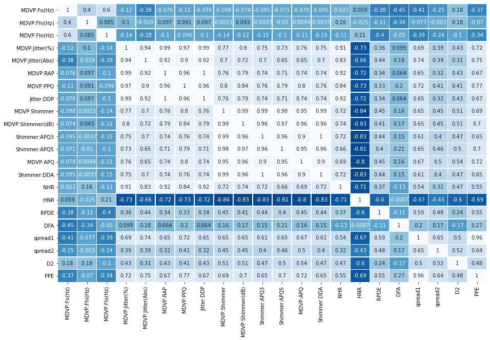

```python
## Plotting the correlation matrix on a heatmap
plt.figure(figsize=[15,10])
sns.heatmap(pk.corr(),
            cmap='Blues_r',
            annot=True,
            linewidths=.5,
            center=0,
            cbar=False
           )
plt.show();
```

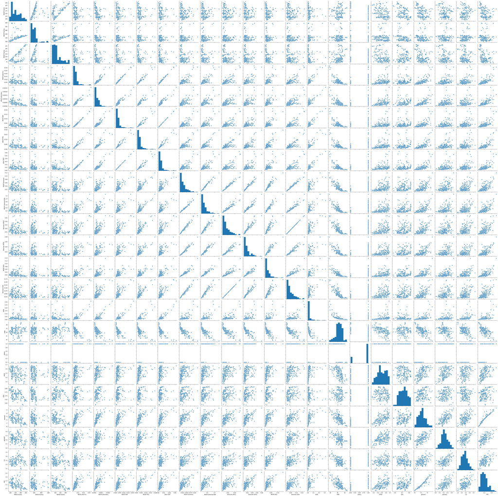

```python
## Visualising relationships using pariplot
sns.pairplot(pk);
```

```python
#Checking the distribution of attributes
pk.describe(include='all').T
```

|  | count | unique | top | freq | mean | std | min | 25% | 50% | 75% | max |
| --- | --- | --- | --- | --- | --- | --- | --- | --- | --- | --- | --- |
| MDVP:Fo(Hz) | 195.0 | NaN | NaN | NaN | 154.228641 | 41.390065 | 88.333000 | 117.572000 | 148.790000 | 182.769000 | 260.105000 |
| MDVP:Fhi(Hz) | 195.0 | NaN | NaN | NaN | 197.104918 | 91.491548 | 102.145000 | 134.862500 | 175.829000 | 224.205500 | 592.030000 |
| MDVP:Flo(Hz) | 195.0 | NaN | NaN | NaN | 116.324631 | 43.521413 | 65.476000 | 84.291000 | 104.315000 | 140.018500 | 239.170000 |
| MDVP:Jitter(%) | 195.0 | NaN | NaN | NaN | 0.006220 | 0.004848 | 0.001680 | 0.003460 | 0.004940 | 0.007365 | 0.033160 |
| MDVP:Jitter(Abs) | 195.0 | NaN | NaN | NaN | 0.000044 | 0.000035 | 0.000007 | 0.000020 | 0.000030 | 0.000060 | 0.000260 |
| MDVP:RAP | 195.0 | NaN | NaN | NaN | 0.003306 | 0.002968 | 0.000680 | 0.001660 | 0.002500 | 0.003835 | 0.021440 |
| MDVP:PPQ | 195.0 | NaN | NaN | NaN | 0.003446 | 0.002759 | 0.000920 | 0.001860 | 0.002690 | 0.003955 | 0.019580 |
| Jitter:DDP | 195.0 | NaN | NaN | NaN | 0.009920 | 0.008903 | 0.002040 | 0.004985 | 0.007490 | 0.011505 | 0.064330 |
| MDVP:Shimmer | 195.0 | NaN | NaN | NaN | 0.029709 | 0.018857 | 0.009540 | 0.016505 | 0.022970 | 0.037885 | 0.119080 |
| MDVP:Shimmer(dB) | 195.0 | NaN | NaN | NaN | 0.282251 | 0.194877 | 0.085000 | 0.148500 | 0.221000 | 0.350000 | 1.302000 |
| Shimmer:APQ3 | 195.0 | NaN | NaN | NaN | 0.015664 | 0.010153 | 0.004550 | 0.008245 | 0.012790 | 0.020265 | 0.056470 |
| Shimmer:APQ5 | 195.0 | NaN | NaN | NaN | 0.017878 | 0.012024 | 0.005700 | 0.009580 | 0.013470 | 0.022380 | 0.079400 |
| MDVP:APQ | 195.0 | NaN | NaN | NaN | 0.024081 | 0.016947 | 0.007190 | 0.013080 | 0.018260 | 0.029400 | 0.137780 |
| Shimmer:DDA | 195.0 | NaN | NaN | NaN | 0.046993 | 0.030459 | 0.013640 | 0.024735 | 0.038360 | 0.060795 | 0.169420 |
| NHR | 195.0 | NaN | NaN | NaN | 0.024847 | 0.040418 | 0.000650 | 0.005925 | 0.011660 | 0.025640 | 0.314820 |
| HNR | 195.0 | NaN | NaN | NaN | 21.885974 | 4.425764 | 8.441000 | 19.198000 | 22.085000 | 25.075500 | 33.047000 |
| status | 195.0 | 2.0 | 1.0 | 147.0 | NaN | NaN | NaN | NaN | NaN | NaN | NaN |
| RPDE | 195.0 | NaN | NaN | NaN | 0.498536 | 0.103942 | 0.256570 | 0.421306 | 0.495954 | 0.587562 | 0.685151 |
| DFA | 195.0 | NaN | NaN | NaN | 0.718099 | 0.055336 | 0.574282 | 0.674758 | 0.722254 | 0.761881 | 0.825288 |
| spread1 | 195.0 | NaN | NaN | NaN | -5.684397 | 1.090208 | -7.964984 | -6.450096 | -5.720868 | -5.046192 | -2.434031 |
| spread2 | 195.0 | NaN | NaN | NaN | 0.226510 | 0.083406 | 0.006274 | 0.174351 | 0.218885 | 0.279234 | 0.450493 |
| D2 | 195.0 | NaN | NaN | NaN | 2.381826 | 0.382799 | 1.423287 | 2.099125 | 2.361532 | 2.636456 | 3.671155 |
| PPE | 195.0 | NaN | NaN | NaN | 0.206552 | 0.090119 | 0.044539 | 0.137451 | 0.194052 | 0.252980 | 0.527367 |

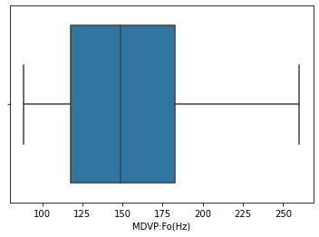

```
For  MDVP:Fo(Hz) - Mean = 154.229, Median = 148.790 and Skewness = 0.592
```

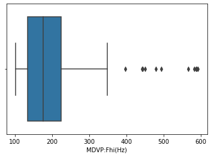

```
For  MDVP:Fhi(Hz) - Mean = 197.105, Median = 175.829 and Skewness = 2.542
```

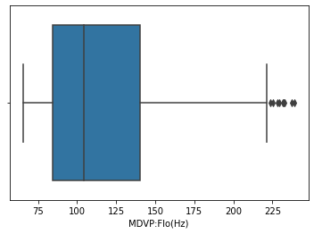

```
For  MDVP:Flo(Hz) - Mean = 116.325, Median = 104.315 and Skewness = 1.217
```

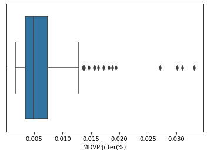

```
For  MDVP:Jitter(%) - Mean = 0.006, Median = 0.005 and Skewness = 3.085
```

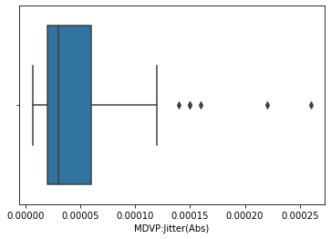

```
For  MDVP:Jitter(Abs) - Mean = 0.000, Median = 0.000 and Skewness = 2.649
```

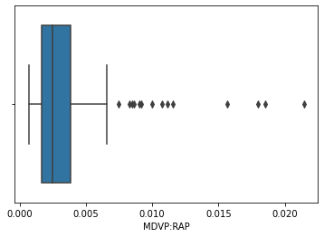

```
For  MDVP:RAP - Mean = 0.003, Median = 0.003 and Skewness = 3.361
```

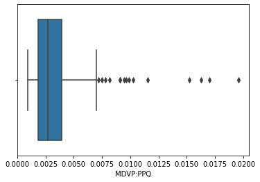

```
For  MDVP:PPQ - Mean = 0.003, Median = 0.003 and Skewness = 3.074
```

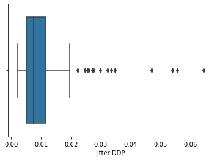

```
For  Jitter:DDP - Mean = 0.010, Median = 0.007 and Skewness = 3.362
```

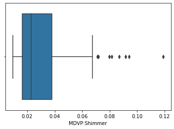

```
For  MDVP:Shimmer - Mean = 0.030, Median = 0.023 and Skewness = 1.666
```

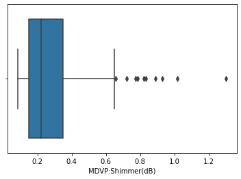

```
For  MDVP:Shimmer(dB) - Mean = 0.282, Median = 0.221 and Skewness = 1.999
```

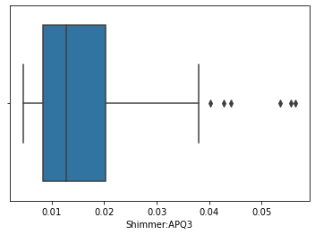

```
For  Shimmer:APQ3 - Mean = 0.016, Median = 0.013 and Skewness = 1.581
```

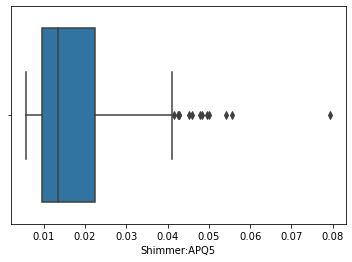

```
For  Shimmer:APQ5 - Mean = 0.018, Median = 0.013 and Skewness = 1.799
```

[10 more figures not shown]

```
For  PPE - Mean = 0.207, Median = 0.194 and Skewness = 0.797
```

```python
## plotting boxplots for tails and outliers and displaying mean, median and skewness of attributes
for cols in pk.drop(columns='status').columns:
    sns.boxplot(pk[cols])
    plt.show();
    print("For ",cols,"- Mean = %.3f, Median = %.3f and Skewness = %.3f" %(pk[cols].mean(),pk[cols].median(),pk[cols].skew()))
```

##### Considering the above graphs and maps, the following additional conclusions can be drawn about the data:

1. MDVP:Fo(Hz)- The data is slightly right skewed with no outliers.
2. MDVP:Fhi(Hz)- The attribute shows multiple outliers between 400 and 600 and the data is highly right skewed.
3. MDVP:Flo(Hz)- The attribute shows a few outliers after 225 and the data is highly right skewed.
4. MDVP:Jitter(%)- The attribute shows multiple outliers between 0.012 and 0.035 and the data is highly right skewed. The attribute shows high correlation with MDVP:Jitter(Abs),MDVP:RAP,MDVP:PPQ,Jitter:DDP and NHR
5. MDVP:Jitter(Abs)- The attribute shows a few outliers after 0.00012 and the data is highly right skewed. The attribute shows high correlation with MDVP:Jitter(%),MDVP:RAP and Jitter:DDP
6. MDVP:RAP- The attribute shows multiple outliers after 0.007 and the data is highly right skewed. The attribute shows high correlation with MDVP:Jitter(%),MDVP:Jitter(Abs),MDVP:PPQ,Jitter:DDP and NHR
7. MDVP:PPQ- The attribute shows multiple outliers after 0.0075 and the data is highly right skewed. The attribute shows high correlation with MDVP:Jitter(%),MDVP:RAP and Jitter:DDP
8. Jitter:DDP- The attribute shows a few outliers after 0.02 and the data is highly right skewed. The attribute shows high correlation with MDVP:Jitter(%),MDVP:Jitter(Abs),MDVP:RAP,MDVP:PPQ and NHR
9. MDVP:Shimmer- The attribute shows a few outliers after 0.07 and the data is right skewed. The attribute shows high correlation with MDVP:Shimmer(dB),Shimmer:APQ3,Shimmer:APQ5,MDVP:APQ and Shimmer:DDA
10. MDVP:Shimmer(dB)- The attribute shows a few outliers after 0.65 and the data is right skewed. The attribute shows high correlation with MDVP:Shimmer,Shimmer:APQ3,Shimmer:APQ5,MDVP:APQ and Shimmer:DDA
11. Shimmer:APQ3- The attribute shows a few outliers after 0.04 and the data is right skewed. The attribute shows high correlation with MDVP:Shimmer,MDVP:Shimmer(dB),Shimmer:APQ5 and Shimmer:DDA
12. Shimmer:APQ5- The attribute shows a few outliers after 0.04 and the data is right skewed. The attribute shows high correlation with MDVP:Shimmer,MDVP:Shimmer(dB),Shimmer:APQ3, MDVP:APQ and Shimmer:DDA
13. MDVP:APQ- The attribute shows outliers after 0.06 and the data is highly right skewed. The attribute shows high correlation with MDVP:Shimmer,MDVP:Shimmer(dB) and Shimmer:APQ5
14. Shimmer:DDA- The attribute shows a few outliers after 0.12 and the data is right skewed. The attribute shows high correlation with MDVP:Shimmer,MDVP:Shimmer(dB),Shimmer:APQ3 and Shimmer:APQ5
15. NHR- The attribute shows multiple outliers after 0.05 and the data is highly right skewed. The attribute shows high correlation with MDVP:Jitter(%),MDVP:RAP and Jitter:DDP
16. HNR- The attribute is slghtly left skewed with a few outliers below 10
17. status - This is the target attribute with around 75% of values as 1
18. RPDE- The attribute is negligibly left skewed with no outliers.
19. DFA- The attribute is negligibly left skewed with no outliers.
20. spread1- The attribute is negligibly right skewed with a few outliers after -3. The attribute has high correlation with PPE
21. spread2- The attribute is distributed in a bell shaped curve with a few outliers on either side.
22. PPE- The attribute is slightly right skewed with a few outliers after 0.425. The attribute has high correlation with spread1

```python
# Calculating the percentge of healthy candidates in overall data
healthy=pk[(pk.status==0)].status.count()
filehealthy=healthy/(pk.status.count())
filehealthy
```

```
0.24615384615384617
```

### Data splitting and verification

```python
# Splitting data into train and test in ratio 7:3
# status as target variable
# Using train_test_split from sklearn.model_selection
X=pk.drop(columns='status')
Y=pk['status']
x_train, x_test, y_train, y_test = train_test_split(X, Y, test_size=0.3, random_state=10)
x_train.head()
```

|  | MDVP:Fo(Hz) | MDVP:Fhi(Hz) | MDVP:Flo(Hz) | MDVP:Jitter(%) | MDVP:Jitter(Abs) | MDVP:RAP | MDVP:PPQ | Jitter:DDP | MDVP:Shimmer | MDVP:Shimmer(dB) | ... | MDVP:APQ | Shimmer:DDA | NHR | HNR | RPDE | DFA | spread1 | spread2 | D2 | PPE |
| --- | --- | --- | --- | --- | --- | --- | --- | --- | --- | --- | --- | --- | --- | --- | --- | --- | --- | --- | --- | --- | --- |
| 49 | 122.964 | 130.049 | 114.676 | 0.00428 | 0.00003 | 0.00124 | 0.00155 | 0.00373 | 0.01681 | 0.154 | ... | 0.01400 | 0.02789 | 0.00462 | 24.971 | 0.538688 | 0.754073 | -6.482096 | 0.264967 | 2.054419 | 0.128872 |
| 180 | 150.440 | 163.441 | 144.736 | 0.00396 | 0.00003 | 0.00206 | 0.00233 | 0.00619 | 0.02551 | 0.237 | ... | 0.02148 | 0.03964 | 0.00611 | 23.133 | 0.352396 | 0.759320 | -6.261446 | 0.183218 | 2.264226 | 0.144105 |
| 102 | 139.224 | 586.567 | 66.157 | 0.03011 | 0.00022 | 0.01854 | 0.01628 | 0.05563 | 0.09419 | 0.930 | ... | 0.06023 | 0.16654 | 0.25930 | 10.489 | 0.596362 | 0.641418 | -3.269487 | 0.270641 | 2.690917 | 0.444774 |
| 151 | 192.818 | 224.429 | 168.793 | 0.03107 | 0.00016 | 0.01800 | 0.01958 | 0.05401 | 0.11908 | 1.302 | ... | 0.13778 | 0.16942 | 0.21713 | 8.441 | 0.625866 | 0.768320 | -2.434031 | 0.450493 | 3.079221 | 0.527367 |
| 91 | 151.955 | 163.335 | 147.226 | 0.00419 | 0.00003 | 0.00224 | 0.00227 | 0.00672 | 0.07959 | 0.772 | ... | 0.05690 | 0.13262 | 0.01658 | 19.664 | 0.501037 | 0.714360 | -6.411497 | 0.207156 | 2.344876 | 0.134120 |

5 rows × 22 columns

```python
#Verifying the ratio of healthy candidates in train set is similar to that in original set
trainhealthy=y_train[y_train==0].count()/y_train.count()
trainhealthy
```

```
0.23529411764705882
```

The percentage of healthy candidates in train data set is approximately equal to that in original dataset, so we can proceed with this random state.

### Data Scaling

###### Since the scale of data is varying for different attributes, we need to scale data for models using distance

Scaled data is required in case of LogisticRegression,KNearestNeighbors and SVM.

```python
## Normalising the data using minmax scalar and fitting to create a new set

norm=prep.MinMaxScaler().fit(x_train)
x_train_norm = norm.transform(x_train)
x_test_norm = norm.transform(x_test)

## Standardising the data using standard scalar and fitting to create a new set
std=prep.StandardScaler().fit(x_train)
x_train_std = std.transform(x_train)
x_test_std = std.transform(x_test)
```

These train data sets will be used to train the LR , KNN and SVM models and the accuracy will be compared with the original. In case of other models, the result would be identical as original sets as they are not dependent on scale and so the models will be fit only on the original datasets.

```python
## defining function to fit the model, print the train and test accuracies and confusion matrix.
## the function would return the following attributes:
# Accuracy, F1 Score, Precision, Recall, False positive values, False negative values and the time taken to execute the model
def fit_n_print(model, X_train, X_test, Y_train, Y_test):  # take the model, train data and test data as input

    start = time.time()  # note the start time

    model.fit(X_train, Y_train)   # fit the model using the train data
    pred = model.predict(X_test)     # model predictions on the test data

    ACR = metrics.accuracy_score(Y_test, pred)  # calculate the accuracy on the test data
    F1 = metrics.f1_score(Y_test, pred)   # F1 score
    PRC = metrics.precision_score(Y_test, pred)  # Root mean squared log error (since the numbers are huge)
    RCL = metrics.recall_score(Y_test, pred)
    print("For model:", model)
    print("Train accuracy=",model.score(X_train,Y_train))
    print("Test accuracy=",ACR)
    end = time.time()  #note the end time
    duration = end - start  # calculate the total duration

    print("Confusion Matrix:")
    cm=metrics.confusion_matrix(Y_test, pred, labels=[1, 0])
    df_cm = pd.DataFrame(cm, index = [i for i in ["1","0"]],
                         columns = [i for i in ["Predict 1","Predict 0"]])
    plt.figure(figsize = (5,3))
    sns.heatmap(df_cm, annot=True, fmt='g',square=True, cmap="Blues")
    plt.show();
    FP = df_cm.iloc[1][0]
    FN = df_cm.iloc[0][1]

    return ACR, F1, PRC, RCL,FP,FN, duration  # return all the metrics along with predictions
```

### Training Standard Classification algorithms

```python
## Definining standard classification algorithms to train on data
lor = LogisticRegression(solver="liblinear")
nbr = nb()
kn = knn(n_neighbors=3,weights = 'distance')
vm = svm.SVC(C=1.8, random_state=10)
dtc = dt(random_state=10)
```

```
For model: LogisticRegression(C=1.0, class_weight=None, dual=False, fit_intercept=True,
                   intercept_scaling=1, l1_ratio=None, max_iter=100,
                   multi_class='auto', n_jobs=None, penalty='l2',
                   random_state=None, solver='liblinear', tol=0.0001, verbose=0,
                   warm_start=False)
Train accuracy= 0.8823529411764706
Test accuracy= 0.8813559322033898
Confusion Matrix:
```

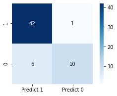

```
For model: LogisticRegression(C=1.0, class_weight=None, dual=False, fit_intercept=True,
                   intercept_scaling=1, l1_ratio=None, max_iter=100,
                   multi_class='auto', n_jobs=None, penalty='l2',
                   random_state=None, solver='liblinear', tol=0.0001, verbose=0,
                   warm_start=False)
Train accuracy= 0.8455882352941176
Test accuracy= 0.864406779661017
Confusion Matrix:
```

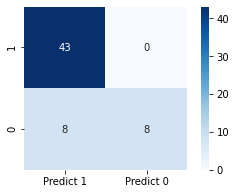

```
For model: LogisticRegression(C=1.0, class_weight=None, dual=False, fit_intercept=True,
                   intercept_scaling=1, l1_ratio=None, max_iter=100,
                   multi_class='auto', n_jobs=None, penalty='l2',
                   random_state=None, solver='liblinear', tol=0.0001, verbose=0,
                   warm_start=False)
Train accuracy= 0.8676470588235294
Test accuracy= 0.8813559322033898
Confusion Matrix:
```

```
For model: KNeighborsClassifier(algorithm='auto', leaf_size=30, metric='minkowski',
                     metric_params=None, n_jobs=None, n_neighbors=3, p=2,
                     weights='distance')
Train accuracy= 1.0
Test accuracy= 0.864406779661017
Confusion Matrix:
```

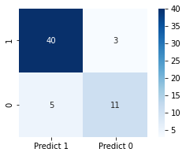

```
For model: KNeighborsClassifier(algorithm='auto', leaf_size=30, metric='minkowski',
                     metric_params=None, n_jobs=None, n_neighbors=3, p=2,
                     weights='distance')
Train accuracy= 1.0
Test accuracy= 0.8983050847457628
Confusion Matrix:
```

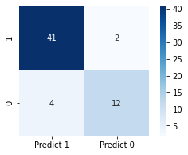

```
For model: KNeighborsClassifier(algorithm='auto', leaf_size=30, metric='minkowski',
                     metric_params=None, n_jobs=None, n_neighbors=3, p=2,
                     weights='distance')
Train accuracy= 1.0
Test accuracy= 0.8813559322033898
Confusion Matrix:
```

```
For model: SVC(C=1.8, break_ties=False, cache_size=200, class_weight=None, coef0=0.0,
    decision_function_shape='ovr', degree=3, gamma='scale', kernel='rbf',
    max_iter=-1, probability=False, random_state=10, shrinking=True, tol=0.001,
    verbose=False)
Train accuracy= 0.8161764705882353
Test accuracy= 0.8305084745762712
Confusion Matrix:
```

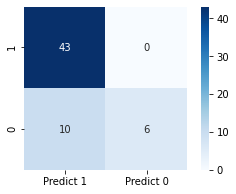

```
For model: SVC(C=1.8, break_ties=False, cache_size=200, class_weight=None, coef0=0.0,
    decision_function_shape='ovr', degree=3, gamma='scale', kernel='rbf',
    max_iter=-1, probability=False, random_state=10, shrinking=True, tol=0.001,
    verbose=False)
Train accuracy= 0.8823529411764706
Test accuracy= 0.8983050847457628
Confusion Matrix:
```

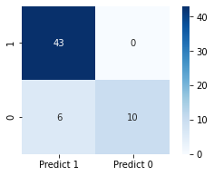

```
For model: SVC(C=1.8, break_ties=False, cache_size=200, class_weight=None, coef0=0.0,
    decision_function_shape='ovr', degree=3, gamma='scale', kernel='rbf',
    max_iter=-1, probability=False, random_state=10, shrinking=True, tol=0.001,
    verbose=False)
Train accuracy= 0.8897058823529411
Test accuracy= 0.9152542372881356
Confusion Matrix:
```

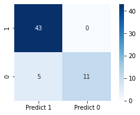

```python
# Creating empty dictionaries to later store metrics of each of the models
resultfile = {}
resultnorm = {}
resultstd = {}

# Using the standard classification models in a for loop
# and appending the results of each of the models to the 'result' dictionary
# Calling the fit_n_print function using original train test data, normalised train test data and standard train test data
for model, name  in zip([lor,kn,vm], ['LogisticRegression','KNearestNeighbors','SVM']):
    resultfile[name] = fit_n_print(model,x_train, x_test,y_train, y_test)
    resultnorm[name] = fit_n_print(model,x_train_norm, x_test_norm,y_train, y_test)
    resultstd[name] = fit_n_print(model,x_train_std, x_test_std,y_train, y_test)
# storing the returned values in the result dict, with name as key
```

The train accuracy, test accuracy and the confusion matrix can be seen above for the 3 models in the order- 1- original split data set, 2- normalised data set, 3- standardised data set.

```
For model: GaussianNB(priors=None, var_smoothing=1e-09)
Train accuracy= 0.6838235294117647
Test accuracy= 0.7796610169491526
Confusion Matrix:
```

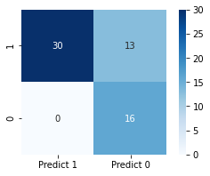

```python
#Calling the fit_n_print function for naive bayes model.
# storing the returned values in resultfile
resultfile['Naive Bayes'] = fit_n_print(nbr,x_train, x_test,y_train, y_test)
```

```python
# making a dataframe out of the metrics from result dictionary for normalised data
resultdfn = pd.DataFrame(np.array(list(resultnorm.values())),
                        columns= ['Accuracy', 'F1 Score', 'Precision score', 'Recall Score',
                                'False Positive','False Negative', 'Elapsed time'],
                        index= resultnorm.keys())   # using the model names as index
resultdfn.index.name = 'Model with nomalised input'   # naming the index to identify normalised input
# Displaying the result dataframe
resultdfn
```

| Model with nomalised input | Accuracy | F1 Score | Precision score | Recall Score | False Positive | False Negative | Elapsed time |
| --- | --- | --- | --- | --- | --- | --- | --- |
| LogisticRegression | 0.864407 | 0.914894 | 0.843137 | 1.000000 | 8.0 | 0.0 | 0.008761 |
| KNearestNeighbors | 0.898305 | 0.931818 | 0.911111 | 0.953488 | 4.0 | 2.0 | 0.017768 |
| SVM | 0.898305 | 0.934783 | 0.877551 | 1.000000 | 6.0 | 0.0 | 0.010406 |

```python
# making a dataframe out of the metrics from result dictionary for stamdardised data
resultdfs = pd.DataFrame(np.array(list(resultstd.values())),
                       columns= ['Accuracy', 'F1 Score', 'Precision score', 'Recall Score',
                                 'False Positive','False Negative', 'Elapsed time'],
                        index= resultstd.keys())   # using the model names as index
resultdfs.index.name = 'Model with standardised input'   # naming the index to identify standardised input
# Displaying the result dataframe
resultdfs
```

| Model with standardised input | Accuracy | F1 Score | Precision score | Recall Score | False Positive | False Negative | Elapsed time |
| --- | --- | --- | --- | --- | --- | --- | --- |
| LogisticRegression | 0.881356 | 0.921348 | 0.891304 | 0.953488 | 5.0 | 2.0 | 0.012875 |
| KNearestNeighbors | 0.881356 | 0.921348 | 0.891304 | 0.953488 | 5.0 | 2.0 | 0.019730 |
| SVM | 0.915254 | 0.945055 | 0.895833 | 1.000000 | 5.0 | 0.0 | 0.016586 |

```python
# making a dataframe out of the metrics from result dictionary for original split data
resultdf = pd.DataFrame(np.array(list(resultfile.values())),
                        columns= ['Accuracy', 'F1 Score', 'Precision score', 'Recall Score',
                                 'False Positive','False Negative', 'Elapsed time'],
                        index= resultfile.keys())   # use the model names as index
resultdf.index.name = 'Model'   # naming the index to identify original datasets
# Displaying the result dataframe
resultdf
```

| Model | Accuracy | F1 Score | Precision score | Recall Score | False Positive | False Negative | Elapsed time |
| --- | --- | --- | --- | --- | --- | --- | --- |
| LogisticRegression | 0.881356 | 0.923077 | 0.875000 | 0.976744 | 6.0 | 1.0 | 0.026899 |
| KNearestNeighbors | 0.864407 | 0.909091 | 0.888889 | 0.930233 | 5.0 | 3.0 | 0.019161 |
| SVM | 0.830508 | 0.895833 | 0.811321 | 1.000000 | 10.0 | 0.0 | 0.013974 |
| Naive Bayes | 0.779661 | 0.821918 | 1.000000 | 0.697674 | 0.0 | 13.0 | 0.022492 |

Since the scores of models are different for different datasets, we need to use the best score out of three for each dataset.

By comparing results, it can be clearly seen that

###### Normalised data gives better scores for KNN

###### Standardised data gives better scores for SVM

Creating a copy of result dataframe for best scores:

```python
# Create copy of original Dataset
resultdfc=resultdf.copy()
## Replace the scores with best scores from Normalised and Standardised datasets
resultdfc.iloc[1]=resultdfn.iloc[1]
resultdfc.iloc[2]=resultdfs.iloc[2]
# Display the updated dataframe
resultdfc
```

| Model | Accuracy | F1 Score | Precision score | Recall Score | False Positive | False Negative | Elapsed time |
| --- | --- | --- | --- | --- | --- | --- | --- |
| LogisticRegression | 0.881356 | 0.923077 | 0.875000 | 0.976744 | 6.0 | 1.0 | 0.026899 |
| KNearestNeighbors | 0.898305 | 0.931818 | 0.911111 | 0.953488 | 4.0 | 2.0 | 0.017768 |
| SVM | 0.915254 | 0.945055 | 0.895833 | 1.000000 | 5.0 | 0.0 | 0.016586 |
| Naive Bayes | 0.779661 | 0.821918 | 1.000000 | 0.697674 | 0.0 | 13.0 | 0.022492 |

### Creating a Meta Classifier

To create a meta classifier, we use the StackingClassifier algorithm from sklearn.ensemble For base estimators(base learners), we will pass the list consisting of logistic regression, K Nearest Neighbors, Decision Trees, svm and Naive Bayes For Final estimator (meta learner), we will pass logistic regression model.

```
For model: StackingClassifier(cv=None,
                   estimators=[('lr',
                                LogisticRegression(C=1.0, class_weight=None,
                                                   dual=False,
                                                   fit_intercept=True,
                                                   intercept_scaling=1,
                                                   l1_ratio=None, max_iter=100,
                                                   multi_class='auto',
                                                   n_jobs=None, penalty='l2',
                                                   random_state=None,
                                                   solver='liblinear',
                                                   tol=0.0001, verbose=0,
                                                   warm_start=False)),
                               ('knn',
                                KNeighborsClassifier(algorithm='auto',
                                                     leaf_size=30,
                                                     metric...
                                GaussianNB(priors=None, var_smoothing=1e-09))],
                   final_estimator=LogisticRegression(C=1.0, class_weight=None,
                                                      dual=False,
                                                      fit_intercept=True,
                                                      intercept_scaling=1,
                                                      l1_ratio=None,
                                                      max_iter=100,
                                                      multi_class='auto',
                                                      n_jobs=None, penalty='l2',
                                                      random_state=None,
                                                      solver='liblinear',
                                                      tol=0.0001, verbose=0,
                                                      warm_start=False),
                   n_jobs=None, passthrough=False, stack_method='auto',
                   verbose=0)
Train accuracy= 0.9852941176470589
Test accuracy= 0.8983050847457628
Confusion Matrix:
```

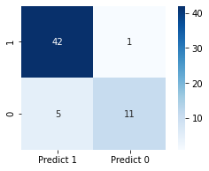

```python
# define base learner models in a list
level0 = list()
level0.append(('lr', lor))
level0.append(('knn', kn))
level0.append(('cart', dtc))
level0.append(('svm', vm))
level0.append(('bayes', nbr))
level0
 #define meta learner model
level1 = lor
# define the stacking ensemble
sc = StackingClassifier(estimators=level0, final_estimator=level1)
## Calling function to fit the model, display confusion matrix and append scores in resultfile
resultfile['Meta Classifier'] = fit_n_print(sc,x_train, x_test,y_train, y_test)
```

It can be noted that while the train accuracy of meta classifier is around 98.5%, its test accuracy is around 90%, hinting overfitting.

### Training Ensemble Models

```python
## Definining ensemble algorithms to train on data
bc = BaggingClassifier(random_state=10)
abc = AdaBoostClassifier(random_state=10)
gbc = GradientBoostingClassifier(random_state=10)
rf = RandomForestClassifier(random_state=10)
```

```
For model: DecisionTreeClassifier(ccp_alpha=0.0, class_weight=None, criterion='gini',
                       max_depth=None, max_features=None, max_leaf_nodes=None,
                       min_impurity_decrease=0.0, min_impurity_split=None,
                       min_samples_leaf=1, min_samples_split=2,
                       min_weight_fraction_leaf=0.0, presort='deprecated',
                       random_state=10, splitter='best')
Train accuracy= 1.0
Test accuracy= 0.8813559322033898
Confusion Matrix:
```

```
For model: BaggingClassifier(base_estimator=None, bootstrap=True, bootstrap_features=False,
                  max_features=1.0, max_samples=1.0, n_estimators=10,
                  n_jobs=None, oob_score=False, random_state=10, verbose=0,
                  warm_start=False)
Train accuracy= 1.0
Test accuracy= 0.9152542372881356
Confusion Matrix:
```

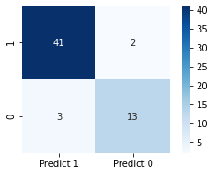

```
For model: AdaBoostClassifier(algorithm='SAMME.R', base_estimator=None, learning_rate=1.0,
                   n_estimators=50, random_state=10)
Train accuracy= 1.0
Test accuracy= 0.847457627118644
Confusion Matrix:
```

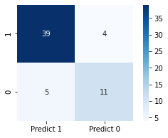

```
For model: GradientBoostingClassifier(ccp_alpha=0.0, criterion='friedman_mse', init=None,
                           learning_rate=0.1, loss='deviance', max_depth=3,
                           max_features=None, max_leaf_nodes=None,
                           min_impurity_decrease=0.0, min_impurity_split=None,
                           min_samples_leaf=1, min_samples_split=2,
                           min_weight_fraction_leaf=0.0, n_estimators=100,
                           n_iter_no_change=None, presort='deprecated',
                           random_state=10, subsample=1.0, tol=0.0001,
                           validation_fraction=0.1, verbose=0,
                           warm_start=False)
Train accuracy= 1.0
Test accuracy= 0.9491525423728814
Confusion Matrix:
```

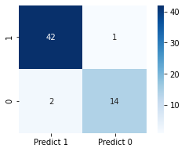

```
For model: RandomForestClassifier(bootstrap=True, ccp_alpha=0.0, class_weight=None,
                       criterion='gini', max_depth=None, max_features='auto',
                       max_leaf_nodes=None, max_samples=None,
                       min_impurity_decrease=0.0, min_impurity_split=None,
                       min_samples_leaf=1, min_samples_split=2,
                       min_weight_fraction_leaf=0.0, n_estimators=100,
                       n_jobs=None, oob_score=False, random_state=10, verbose=0,
                       warm_start=False)
Train accuracy= 1.0
Test accuracy= 0.9322033898305084
Confusion Matrix:
```

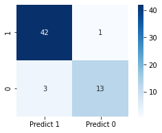

```python
# using the ensemble models in a for loop
# and appending the results of each of the models to the 'resultfile' dictionary
## Calling function to fit the model, display confusion matrix and append scores in resultfile
for model, name  in zip([dtc, bc,abc,gbc, rf], ['Decision Tree','Bagging Ensemble',
                                                'Adaptive Boost Ensemble','Gradient Boost Ensemble','Random Forest']):
    resultfile[name] = fit_n_print(model,x_train, x_test,y_train, y_test)
```

```python
 # making a dataframe out of the metrics from result dictionary
resultdf = pd.DataFrame(np.array(list(resultfile.values())),
                        columns= ['Accuracy', 'F1 Score', 'Precision score', 'Recall Score',
                                 'False Positive','False Negative', 'Elapsed time'],
                        index= resultfile.keys())   # using the model names as index
resultdf.index.name = 'Model'
# Displaying the result dataframe
resultdf
```

| Model | Accuracy | F1 Score | Precision score | Recall Score | False Positive | False Negative | Elapsed time |
| --- | --- | --- | --- | --- | --- | --- | --- |
| LogisticRegression | 0.881356 | 0.923077 | 0.875000 | 0.976744 | 6.0 | 1.0 | 0.026899 |
| KNearestNeighbors | 0.864407 | 0.909091 | 0.888889 | 0.930233 | 5.0 | 3.0 | 0.019161 |
| SVM | 0.830508 | 0.895833 | 0.811321 | 1.000000 | 10.0 | 0.0 | 0.013974 |
| Naive Bayes | 0.779661 | 0.821918 | 1.000000 | 0.697674 | 0.0 | 13.0 | 0.022492 |
| Meta Classifier | 0.898305 | 0.933333 | 0.893617 | 0.976744 | 5.0 | 1.0 | 0.234900 |
| Decision Tree | 0.881356 | 0.921348 | 0.891304 | 0.953488 | 5.0 | 2.0 | 0.015539 |
| Bagging Ensemble | 0.915254 | 0.942529 | 0.931818 | 0.953488 | 3.0 | 2.0 | 0.058370 |
| Adaptive Boost Ensemble | 0.847458 | 0.896552 | 0.886364 | 0.906977 | 5.0 | 4.0 | 0.162498 |
| Gradient Boost Ensemble | 0.949153 | 0.965517 | 0.954545 | 0.976744 | 2.0 | 1.0 | 0.171431 |
| Random Forest | 0.932203 | 0.954545 | 0.933333 | 0.976744 | 3.0 | 1.0 | 0.227011 |

### Model comparison

```python
## Since for standard classifiers, the scores were better in standardised or normalised data, using those scores
## Displaying the best scores for comparison
resultdfc.append(resultdf.iloc[4:])
```

| Model | Accuracy | F1 Score | Precision score | Recall Score | False Positive | False Negative | Elapsed time |
| --- | --- | --- | --- | --- | --- | --- | --- |
| LogisticRegression | 0.881356 | 0.923077 | 0.875000 | 0.976744 | 6.0 | 1.0 | 0.026899 |
| KNearestNeighbors | 0.898305 | 0.931818 | 0.911111 | 0.953488 | 4.0 | 2.0 | 0.017768 |
| SVM | 0.915254 | 0.945055 | 0.895833 | 1.000000 | 5.0 | 0.0 | 0.016586 |
| Naive Bayes | 0.779661 | 0.821918 | 1.000000 | 0.697674 | 0.0 | 13.0 | 0.022492 |
| Meta Classifier | 0.898305 | 0.933333 | 0.893617 | 0.976744 | 5.0 | 1.0 | 0.234900 |
| Decision Tree | 0.881356 | 0.921348 | 0.891304 | 0.953488 | 5.0 | 2.0 | 0.015539 |
| Bagging Ensemble | 0.915254 | 0.942529 | 0.931818 | 0.953488 | 3.0 | 2.0 | 0.058370 |
| Adaptive Boost Ensemble | 0.847458 | 0.896552 | 0.886364 | 0.906977 | 5.0 | 4.0 | 0.162498 |
| Gradient Boost Ensemble | 0.949153 | 0.965517 | 0.954545 | 0.976744 | 2.0 | 1.0 | 0.171431 |
| Random Forest | 0.932203 | 0.954545 | 0.933333 | 0.976744 | 3.0 | 1.0 | 0.227011 |

##### Comparing the scores from various models, following conclusions can be reported:

Amongst all the models, the top scorers in accuracy are Gradient Boost, Random Forest, Bagging Ensemble and SVM. But considering the case study, minimal false negative is the objective as Healthy candidate reported suffering from Parkinsons is better than Sick candidate reported as healthy. Consequently, the top scorers in recall are SVM, Gradient Boost, Random Forest, LR and Meta classifier.

Overall, Comparing the False positive values keeping false negative minimum, and considering the elapsed time as well as accuracy, the best models emerge to be :

1. SVM(with standardised data):

Accuracy at 91.5

And perfect recall with 0 False negatives

1. Gradient Boost

High Recall score(97.7%) with 1 FN

High Accuracy (95%)

Depending upon the threshold for FN and Accuracy, we can choose either SVM or gradient boost But given the case study and all the associated parameters, SVM with Standardised input performs the best and Gradient Boost performs best on original datasets(second best if standardised input is considered)